# An introduction to programming with R

## Basics of programming

- Many modern scientific problems/tasks are too larger or too complex (or both) to *solve* without the aid of computers
  - some problems are hard to even visualize/imagine without computers
- Programming is the act of providing computers with specific operational instructions; usually to assist (us) with performing a specific task or solving a specific problem
- Can provide instructions via mouse and keyboard (i.e., use a software tool); but the majority of programming (coding) is done through written instructions called **source code**

## Basics of programming

- the programming *language* used to write source code depends on:
  - the hardware/software of the computer (or instrument)
    - i.e., what can the computer process/understand
  - the task/problem being worked on
  - the skills/experience of the programmer

## Basics of programming

- one major dichotomy to know:
  - **Compiled Languages:** source code gets compiled by an *operating system specific compiler* into an **executable file** (application) that can then be run directly by the operating system
    - language has a steeper learning curve, but the resulting applications run very efficiently
  - **Interpreted Languages:** source code is executed by an interpreter (application) which being run on the operating system
    - language is more human-readable, but usually inefficient
- In this class we’ll be working with the R programming language

## Programming in R

- To write R code, all you need is to know the language!
- To *run* R code, all you need to have is:
  - A computer with any modern operating system (Windows, Max, Linux)
  - A text editor installed on the computer
  - The appropriate version of “R” (the interpreter) installed on the computer www.cran.r-project.org
- RStudio is an integrated development environment (IDE) application
  - allows you to view/edit code, run the code, visualize outputs in a console, and view all the variables currently loaded in the interpreting environment

## Errors

- syntax are the set of rules/procedures for working with a language (grammarPlus)
  - compilers/interpreters are very sensitive to syntax–you need to follow the rules of your language for your code to run (syntax errors)
- compilers/interpreters are more literal than humans
  - you need to make sure your logic is precise for your code to output the correct answer (logic errors)
- if your computer is not following the instructions you’ve provided, there is either a syntax error, a logic error, or a memory leak

## Some key R syntax

```r
#                   # ignores text that follows until the next line (comment)
x <- 7              # create a variable x and assign it the value 7
y = 8               # create a variable y and assign it the value 8
z = x + y           # create a variable z and assign it the value of x + y
zebra = x^2         # create a variable zebra and assigned the value of x to the power 2
```

```r
print(zebra)            # the function "print" displays the value of zebra maintaining its "shape"
```

```r
ebra = zebra - z      # creates a variable ebra and assign it the value of zebra - z
cat(ebra)             # the function "cat" displays the value of variable ebra
```

```r
cat(zebra - z)      # the function "cat" displays the value of variable zebra - z
```

## Some key R syntax

```r
cat("This is a test")   # display the string "This is a test"
# cat(test)             # this code will fail because there is no variable named test in our environment
```

```r
zebra_sentence = paste0("The value of zebra is ",zebra) # The paste0 function will glue things together without including any spaces
cat(zebra_sentence)
```

```r
cat(paste0("The value of ebra is ",ebra) )
```

## Objects in R

- Some key types of objects to be aware of:
  - variable: stores a single value, can be a number or character
  - array: stores multiple values, can contain numbers XOR characters (vectors + matrices)
  - data frames: multiple arrays, can be any data type but will force a “shape” on the data
  - lists: multiple variables, arrays, etc.. can be any data type AND any shape

```r
 rm(list=ls())        # the ls() function finds all objects in the environment, the rm() function removes and lists that are provided to it

 x = c(1, 2, 3, 4, 5) # creates an array x and assigns it the values 1 through 5 using the the "collect" function
 y = seq(1,5,1)       # creates an array y and assigns it the values 1 through 5 increments of 1 using the "sequence" function
 z = seq(1,5,0.1)     # creates an array z and assigns it the values 1 through 5 by increments of 0.1 using the "sequence"
```

## Objects in R

```r
 xy = cbind(x,y)      # use the "cbind" function create a matrix xy with columns equal to x and y
 print(xy)
```

```
     x y
[1,] 1 1
[2,] 2 2
[3,] 3 3
[4,] 4 4
[5,] 5 5
```

```r
  cat(xy)
```

```
1 2 3 4 5 1 2 3 4 5
```

## Importing data in R

- R is a general purpose programming language, but it is popular because of its rich repository of powerful statistics and data analysis functions
  - Reading and writing data
  - Regression modeling
  - Hypothesis testing
  - Machine learning

```r
  rm(list=ls())                 # clear work space
  Spec1 = read.table("U1.txt")  # create an array Spec1 and assign it the values from the text file U1.txt using the read.table function
  # the first column is m/z values and second column are intensity values
  nPeaks = nrow(Spec1)          # create a variable nPeaks and assign it the value of the number of rows in the array Spec1 using the nrow function
  nPeaks                        # instead of using the print or cat function, in the console we can just type the variable name and its value will get printed on the screen
```

```
[1] 80
```

## Work with mass spectral data

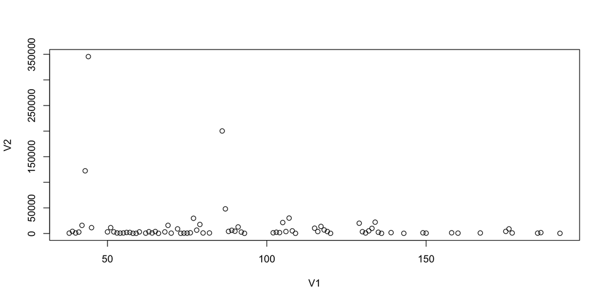

```r
plot(Spec1) # use the plot function to create a scatter plot of the x,y value in Spec1
```

**Issues:** atypical for plotting mass spectra (raw abundance scores, and scatter plot)

## Work with mass spectral data

```r
mz = Spec1[,1]      # with an array, we can extract specific columns, rows and cell values
int = Spec1[,2]
int = int/max(int)  # normalizes the intensity values to 1

plot(mz,
     int,
     type="h",
     xlab="mass-to-charge ratio",
     ylab="relative intensity") # use the plot function to create a scatter plot of the x,y value in Spec1
```

[output not shown]

**Issues:** a lot of low intensity peaks that could be artifacts

## Work with mass spectral data

```r
noisePeaks = which(int<=0.01) # identify the values in the intensity array that have relative intensity less than 1%

if(length(noisePeaks)>0){   # checks to see if any noise peaks were identified, if yes runs code in the "chunck"
  mz = mz[-noisePeaks]
  int = int[-noisePeaks]
}

plot(mz,
     int,
     type="h",
     xlab="mass-to-charge ratio",
     ylab="relative intensity") # use the plot function to create a scatter plot of the x,y value in Spec1
```

[output not shown]

**Homework challenge:** write some code to determine the mass-to-charge ratio of the base peak of this spectrum

## Working in the console versus writing a script

- Why write and save scripts?
  - allows you to easily update and re-run your source code
  - allows you to share your source code with other people
- Why work in the console?
  - to test some ideas out or compute something quickly
- >90% of the time, you’ll want to write a script

## Coming up

- Seminars are running in-person on Thursday October 15th
  - F01 (SC 204) and F02 (SC W1)
- **SPECIAL Lecture next week:** Graduate school in Canada
  - Guests will be joining us via Zoom